# R_notebook_for_reproduced_results

## Artic title: Repeated inoculation with rumen fluid before or during weaning modulated

the microbiota composition and co-occurrence of the rumen and colon of lambs

## data accessiblity

data set were reposit on “R.data” file this reproduced script will start from the OTU table generate from qiime software

### get packages we needed

```r
library(ggplot2)
library(ggsci)
library(reshape2)
library(car)
library(vegan)
library(rcompanion)
library(agricolae)
library(Hmisc)
```

load workspace

```r
load("~/Desktop/16s_shaobo/reproduced/data_reproduced_shao_inoculation.RData")
```

## statistic for production data (BW, fermentation, carcass measurement)

```r
head(production_data)
```

|  | fID | group | Triplets | BW | TADG | week2 | week3 | week4 | Total.VFA | Rumenacetate | Rumenpropionate | Rumenisobutyrate | Rumenbutyrate | Rumenisovalerate | Rumenvalerate | RumenAce.Pro | RumenNH4 | RumenAccumulate.Intake | RumenPH | Rumenweight | Reticulumweight | Omasumweight | Abomasumweight | Smallintestine | Largeintestine | Colonweight | SIL | LIL | TIL | … |
| --- | --- | --- | --- | --- | --- | --- | --- | --- | --- | --- | --- | --- | --- | --- | --- | --- | --- | --- | --- | --- | --- | --- | --- | --- | --- | --- | --- | --- | --- | --- |
| 1 | 841 | BT | Triplets1 | 3.600 | 0.04042857 | 0.06428571 | 0.09285714 | -0.035714286 | 59.71911 | 0.6668796 | 0.1765260 | 0.016653014 | 0.09067133 | 0.02582197 | 0.02344809 | 3.777799 | 0.16410909 | 124.50 | 6.160 | 8.502778 | 1.725000 | 1.113889 | 6.955556 | 25.08056 | 9.261111 | 4.538889 | 166.1111 | 32.77778 | 198.8889 | … |
| 2 | 846 | BT | Triplets2 | 3.200 | 0.03228571 | 0.07857143 | 0.05000000 | -0.032142857 | 70.00970 | 0.6245532 | 0.1943240 | 0.011442418 | 0.12636067 | 0.01405606 | 0.02926371 | 3.213979 | 0.08819379 | 108.65 | 5.534 | 12.056250 | 3.175000 | 1.128125 | 7.506250 | 30.10625 | 10.750000 | 4.562500 | 200.3125 | 43.90625 | 244.2188 | … |
| 3 | 849 | BT | Triplets3 | 3.450 | 0.04519048 | 0.06428571 | 0.09285714 | -0.021428571 | 64.42832 | 0.5983497 | 0.2368677 | 0.008636009 | 0.12004988 | 0.02371228 | 0.01238448 | 2.526092 | 0.20077694 | 93.66 | 5.368 | 14.782609 | 2.194203 | 1.359420 | 8.260870 | 27.56812 | 9.657971 | 5.420290 | 172.6087 | 37.97101 | 210.5797 | … |
| 4 | 874 | BT | Triplets4 | 3.600 | 0.03800000 | 0.05000000 | 0.08928571 | -0.025000000 | 53.15939 | 0.6901573 | 0.1670777 | 0.021152957 | 0.06526835 | 0.03115743 | 0.02518628 | 4.130756 | 0.96533430 | 82.96 | 5.757 | 4.088889 | 1.930556 | 2.466667 | 6.461111 | 20.95000 | 6.319444 | 3.405556 | 164.3056 | 42.50000 | 206.8056 | … |
| 5 | 875 | BT | Triplets5 | 2.825 | 0.04395238 | 0.05000000 | 0.08928571 | -0.007142857 | 31.05497 | 0.6943412 | 0.1914631 | 0.024703936 | 0.04593575 | 0.02121281 | 0.02234319 | 3.626500 | 0.07988064 | 113.40 | 6.064 | 12.010619 | 3.642478 | 1.136283 | 7.649558 | 32.74690 | 10.594690 | 5.380531 | 202.3009 | 51.32743 | 253.6283 | … |
| 6 | 843 | AT | Triplets1 | 3.275 | 0.05123809 | 0.06785714 | 0.10000000 | -0.014285714 | 63.46634 | 0.5791541 | 0.2117639 | 0.000000000 | 0.14675568 | 0.01310646 | 0.04921989 | 2.734905 | 0.53189827 | 113.38 | 5.390 | 9.819847 | 2.937405 | 1.819847 | 8.204580 | 32.61374 | 10.015267 | 4.638168 | 201.5267 | 35.26718 | 236.7939 | … |

### take rumen isovalerate as example (parametric significance)

```r
shapiro.test(production_data$Rumenisovalerate) #### normality
```

```
##
##  Shapiro-Wilk normality test
##
## data:  production_data$Rumenisovalerate
## W = 0.96385, p-value = 0.7857
```

```r
leveneTest(production_data$Rumenisovalerate ~ group, data = production_data) #### levene test
```

|  | Df | F value | Pr(>F) |
| --- | --- | --- | --- |
| group | 2 | 0.2873038 | 0.7557449 |
|  | 11 | NA | NA |

```r
leveneTest(production_data$Rumenisovalerate ~ Triplets, data = production_data) #### levene test
```

|  | Df | F value | Pr(>F) |
| --- | --- | --- | --- |
| group | 4 | 0.1576254 | 0.9545764 |
|  | 9 | NA | NA |

```r
aov_vfa <- aov(Rumenisovalerate ~ group + Triplets,data = production_data)  ###two way anova without interaction
```

```r
summary(aov_vfa)
```

```
##             Df    Sum Sq   Mean Sq F value  Pr(>F)
## group        2 0.0004502 2.251e-04  12.880 0.00451 **
## Triplets     4 0.0004303 1.076e-04   6.156 0.01901 *
## Residuals    7 0.0001223 1.748e-05
## ---
## Signif. codes:  0 '***' 0.001 '**' 0.01 '*' 0.05 '.' 0.1 ' ' 1
## 1 observation deleted due to missingness
```

```r
library(emmeans)
model.tukey <- emmeans(aov_vfa, pairwise ~ group)[[2]]
```

```r
model.tukey
```

```
##  contrast     estimate          SE df t.ratio p.value
##  AT - BT  -0.007042042 0.002643954  7  -2.663  0.0735
##  AT - C    0.009312781 0.002881182  7   3.232  0.0339
##  BT - C    0.016354823 0.002881182  7   5.676  0.0019
##
## Results are averaged over the levels of: Triplets
## P value adjustment: tukey method for comparing a family of 3 estimates
```

### take colon weight as example (nonparametric significance)

```r
shapiro.test(production_data$Colonweight)
```

```
##
##  Shapiro-Wilk normality test
##
## data:  production_data$Colonweight
## W = 0.80054, p-value = 0.005067
```

```r
library(lmPerm)
aov_perm <- aovp(production_data$Colonweight ~ group+Triplets,data=production_data,perm = "Prob",maxIter = 999)
```

```
## [1] "Settings:  unique SS "
```

```r
summary(aov_perm)
```

```
## Component 1 :
##             Df R Sum Sq R Mean Sq Iter Pr(Prob)
## group        2   30.027   15.0135  999  0.01902 *
## Triplets     4   15.657    3.9142  999  0.13914
## Residuals    7   12.611    1.8015
## ---
## Signif. codes:  0 '***' 0.001 '**' 0.01 '*' 0.05 '.' 0.1 ' ' 1
```

(pvalue could be different because of the permutation)

pairwise permutation

```r
pairwisePermutationTest(x= production_data$Colonweight,g= production_data$group,data = production_data,method="fdr")
```

| Comparison | Stat | p.value | p.adjust |
| --- | --- | --- | --- |
| AT - BT = 0 | 0.9463 | 0.344 | 0.34400 |
| AT - C = 0 | -1.923 | 0.05445 | 0.08168 |
| BT - C = 0 | -2.073 | 0.03817 | 0.08168 |

significant tendancy between AT vs C and BT vs C all measurement were conducted by test above for significance

## alpha diversity

first, alpha diversity in phyloseq with OTU table, metadata and phylogenetic tree, qiime data were imported as “content”" (a phyloseq dataset) alpha diversity could also be genrated from qiime software

```r
library(phyloseq)
set.seed(0116)  #### if nessary, date could be appropriate
##rarefaction
content_even <- rarefy_even_depth(content)
```

```
## You set `rngseed` to FALSE. Make sure you've set & recorded
##  the random seed of your session for reproducibility.
## See `?set.seed`
```

```
## ...
```

```r
###alpha diversity
###generate distance metrix
alpha <- estimate_richness(content_even, measures=c("Observed", "Shannon", "Chao1"))

###give the metadata
alpha$Fraction <- content_even@sam_data@.Data[[3]]
alpha$Inoculation <- content_even@sam_data@.Data[[4]]
alpha$Triplets <- content_even@sam_data@.Data[[7]]
```

```r
head(alpha)
```

|  | Observed | Chao1 | se.chao1 | Shannon | Fraction | Inoculation | Triplets |
| --- | --- | --- | --- | --- | --- | --- | --- |
| RMC2 | 567 | 575.2609 | 5.047177 | 5.359273 | RC | I | Adult sheep |
| RMC1 | 557 | 568.4000 | 6.955868 | 5.088232 | RC | I | Adult sheep |
| RMC5 | 552 | 566.0000 | 7.073552 | 5.300045 | RC | I | Adult sheep |
| RMC4 | 561 | 586.3750 | 12.454119 | 5.482292 | RC | I | Adult sheep |
| RMC3 | 558 | 576.6000 | 8.833008 | 5.323958 | RC | I | Adult sheep |
| CC872 | 379 | 411.5714 | 11.382493 | 3.329495 | CC | C | Triplets4 |

```r
###split
alpha_no_inoculum <- alpha[alpha$Inoculation != "I",]
alpha_rc <- alpha_no_inoculum[alpha_no_inoculum$Fraction == "RC",]
alpha_cc <- alpha_no_inoculum[alpha_no_inoculum$Fraction == "CC",]
```

### statistic

```r
#take shannon index in colon content as example
shapiro.test(alpha_cc$Shannon) #### normality
```

```
##
##  Shapiro-Wilk normality test
##
## data:  alpha_cc$Shannon
## W = 0.87366, p-value = 0.0382
```

```r
leveneTest(alpha_cc$Shannon ~ Inoculation, data = alpha_cc) #### levene test
```

|  | Df | F value | Pr(>F) |
| --- | --- | --- | --- |
| group | 2 | 0.2777185 | 0.7622484 |
|  | 12 | NA | NA |

```r
leveneTest(alpha_cc$Shannon ~ Triplets, data = alpha_cc) #### levene test
```

|  | Df | F value | Pr(>F) |
| --- | --- | --- | --- |
| group | 4 | 0.4598124 | 0.7638494 |
|  | 10 | NA | NA |

we use permutation anova test in lmPerm package

```r
library(lmPerm)
summary(aovp(Shannon ~ Inoculation + Triplets,data=alpha_cc,perm = "Prob", maxIter = 999))  ###two way anova without interaction
```

```
## [1] "Settings:  unique SS "
```

```
## Component 1 :
##              Df R Sum Sq R Mean Sq Iter Pr(Prob)
## Inoculation1  2  0.30826   0.15413  100   0.6600
## Triplets1     4  1.87786   0.46946  999   0.1782
## Residuals     8  2.28829   0.28604
```

p-value could be different cause iteration is different every run! (non-parametric data)

## beta diversity

```r
###generate distance metrix
dist <- distance(content_even, method = "bray")

###plot NMDS plot with distance
ordu_content = ordinate(content_even, "NMDS", "bray")
```

```
## Square root transformation
## Wisconsin double standardization
## *** No convergence -- monoMDS stopping criteria:
##     17: stress ratio > sratmax
##      3: scale factor of the gradient < sfgrmin
```

```r
plot_1 <- plot_ordination(content_even, ordu_content, axes=c(1,2),color="Inoculation")+
  geom_point(size=3,aes(shape=Fraction))+
  #stat_ellipse()+
  scale_color_nejm(name="Fraction:")+
  scale_shape_manual(name="Inoculation:",values=c(15,16,17,18,6))+
  theme_bw()+
  #xlab("PC1 16.4%")+
  #ylab("PC2 13.4%")+
  labs(caption="NMDS plot of Bray-Curtis Distance")+
  theme(axis.text = element_text(size=14,color = "black"),
        rect=element_rect(size=1,color="black"),
        axis.line = element_line(size=1),
        line = element_line(size=1),
        #legend.position = "none",
        plot.title=element_text(size=20,hjust = 0,vjust = 0),
        axis.title = element_text(size=18),
        plot.caption = element_text(size = 20,hjust = 0),
        panel.grid = element_blank(),
        plot.margin = margin(18,18,18,18))
```

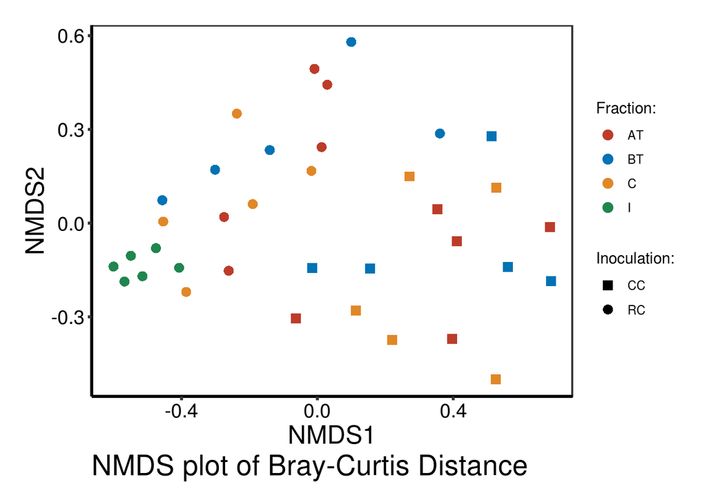

```r
##see what we get
plot_1
```

Figure 2 got!

statistic

```r
metadata <- as(sample_data(content_even), "data.frame")
```

```r
library(RVAideMemoire)
###adonis
adonis(dist ~ Fraction,data = metadata,permutations = 999)
```

```
##
## Call:
## adonis(formula = dist ~ Fraction, data = metadata, permutations = 999)
##
## Permutation: free
## Number of permutations: 999
##
## Terms added sequentially (first to last)
##
##           Df SumsOfSqs MeanSqs F.Model      R2 Pr(>F)
## Fraction   1    1.7582 1.75820  8.6595 0.20299  0.001 ***
## Residuals 34    6.9032 0.20304         0.79701
## Total     35    8.6614                 1.00000
## ---
## Signif. codes:  0 '***' 0.001 '**' 0.01 '*' 0.05 '.' 0.1 ' ' 1
```

```r
adonis(dist ~ Inoculation,data = metadata,permutations = 999)
```

```
##
## Call:
## adonis(formula = dist ~ Inoculation, data = metadata, permutations = 999)
##
## Permutation: free
## Number of permutations: 999
##
## Terms added sequentially (first to last)
##
##             Df SumsOfSqs MeanSqs F.Model      R2 Pr(>F)
## Inoculation  3    1.8046 0.60154  2.8074 0.20835  0.001 ***
## Residuals   32    6.8568 0.21428         0.79165
## Total       35    8.6614                 1.00000
## ---
## Signif. codes:  0 '***' 0.001 '**' 0.01 '*' 0.05 '.' 0.1 ' ' 1
```

```r
####pairwise perm test
pairwise.perm.manova(dist,content_even@sam_data@.Data[[2]],nperm = 999)
```

```
##
##  Pairwise comparisons using permutation MANOVAs on a distance matrix
##
## data:  dist by content_even@sam_data@.Data[[2]]
## 999 permutations
##
##      CCAT  CCBT  CCC   I     RCAT  RCBT
## CCBT 0.399 -     -     -     -     -
## CCC  0.923 0.683 -     -     -     -
## I    0.017 0.017 0.017 -     -     -
## RCAT 0.022 0.022 0.017 0.017 -     -
## RCBT 0.022 0.017 0.022 0.017 0.205 -
## RCC  0.017 0.017 0.035 0.017 0.696 0.122
##
## P value adjustment method: fdr
```

again, p-value could be different because of the permutation

## select mature rumen microbes

### genera level selection

genera abundance table were generate in qiime

```r
generaname <- colnames(genera_abundance)[-1:-5]  ##extract genera name
genera_with_pvalue <- genera_abundance

##loop of kruskal to get mature rumen microbes
for (i in generaname){
  if (sum(genera_abundance[,i])>0){
    temp <- with(genera_abundance,kruskal(genera_abundance[,i][1:11],genera_abundance$Description[1:11],group=TRUE, main="genera_abundance"))
    if (temp$statistics$p.chisq < 0.05){genera_with_pvalue["pvalue",i] = temp$statistics$p.chisq}
  }
}

genera_mature <- cbind(genera_with_pvalue[,1:5],genera_with_pvalue[,!is.na(genera_with_pvalue["pvalue",])])

genera_mature <- genera_mature[1:36,]
```

friedman test to evaluate the introduced taxa (increased abundance)

In rumen, BT vs C as example

```r
mature_name <- colnames(genera_mature)[-1:-5]  ##mature genera name
genera_mature_rumen_bt_c <- genera_mature[7:16,]  ##subgroup

##facter levels
genera_mature_rumen_bt_c$Triplets <- factor(genera_mature_rumen_bt_c$Triplets,levels = unique(genera_mature_rumen_bt_c$Triplets))
genera_mature_rumen_bt_c$Inoculation <- factor(genera_mature_rumen_bt_c$Inoculation,levels = unique(genera_mature_rumen_bt_c$Inoculation))

genera_mature_introduced <- genera_mature_rumen_bt_c


##select introduced genera
for (i in mature_name) {
  out<-with(genera_mature_rumen_bt_c,friedman(Triplets,Inoculation,genera_mature_rumen_bt_c[1:10,i],alpha=0.05, group=TRUE,console=TRUE,
                         main="Data of the inoculation"))
  if (out$statistics$p.chisq <0.05){
    genera_mature_introduced["pvalue",i] <- out$statistics$p.chisq
  }
  else {
      genera_mature_introduced["pvalue",i] <- NA}
}
```

[output not shown]

[output cut: 1569 more lines]

```
## P.Value Chisq: 0.6547208
## F Value: 0.1666667
## P.Value F: 0.704
##
## Post Hoc Analysis
##
## Alpha: 0.05 ; DF Error: 4
## t-Student: 2.776445
## LSD: 6.800874
##
## Treatments with the same letter are not significantly different.
##
##    Sum of ranks groups
## BT            8      a
## C             7      a
```

```r
genera_mature_introduced <- genera_mature_introduced[,!is.na(genera_mature_introduced["pvalue",])]
```

introduced in IBW (only increase)

```r
colnames(genera_mature_introduced)
```

```
## [1] "D_0__Bacteria.D_1__Bacteroidetes.D_2__Bacteroidia.D_3__Bacteroidales.D_4__Prevotellaceae.D_5__Prevotellaceae.UCG.001"
## [2] "D_0__Bacteria.D_1__Firmicutes.D_2__Clostridia.D_3__Clostridiales.D_4__Family.XIII.D_5__Mogibacterium"
## [3] "D_0__Bacteria.D_1__Firmicutes.D_2__Clostridia.D_3__Clostridiales.D_4__Lachnospiraceae.D_5__Moryella"
## [4] "D_0__Bacteria.D_1__Firmicutes.D_2__Clostridia.D_3__Clostridiales.D_4__Lachnospiraceae.D_5__Tyzzerella.4"
## [5] "D_0__Bacteria.D_1__Firmicutes.D_2__Clostridia.D_3__Clostridiales.D_4__Lachnospiraceae.D_5__probable.genus.10"
## [6] "D_0__Bacteria.D_1__Firmicutes.D_2__Negativicutes.D_3__Selenomonadales.D_4__Acidaminococcaceae.D_5__Succiniclasticum"
```

within these, Mogibacterium and probable.genus.10 is reducing, so delete them!

then use genera_mature, transfer to z-score, and use complexheatmap for illustrate.

### OTU level selection

generally, same as genera level,extract significantly different OTUs (mature OTUs) and select introduced OTUs

## Co-occurrence analysis

select all introduced OTUs and LEfSe biomarker OTUs in rumen manually

```r
##import data
head(otu_selected)
```

|  | OTU.ID | Inoculation | Description | OTU102 | OTU379 | OTU390 | OTU245 | OTU1763 | OTU380 | OTU169 | OTU59 | OTU51 | OTU421 | OTU232 | OTU141 | OTU10 | OTU2235 | OTU67 | OTU1102 | OTU483 | OTU480 | OTU742 | OTU79 | OTU447 | OTU308 | OTU440 | OTU1450 | OTU137 | OTU80 | … |
| --- | --- | --- | --- | --- | --- | --- | --- | --- | --- | --- | --- | --- | --- | --- | --- | --- | --- | --- | --- | --- | --- | --- | --- | --- | --- | --- | --- | --- | --- | --- |
| 1 | RMC1 | I | I | 182 | 23 | 3 | 68 | 17 | 14 | 186 | 420 | 29 | 7 | 22 | 50 | 278 | 42 | 279 | 4 | 7 | 12 | 14 | 340 | 9 | 9 | 7 | 12 | 126 | 246 | … |
| 2 | RMC2 | I | I | 199 | 23 | 16 | 87 | 36 | 12 | 158 | 631 | 99 | 11 | 47 | 92 | 231 | 47 | 380 | 22 | 19 | 32 | 23 | 321 | 5 | 25 | 10 | 4 | 105 | 257 | … |
| 3 | RMC3 | I | I | 254 | 9 | 11 | 78 | 50 | 14 | 410 | 806 | 88 | 78 | 26 | 101 | 147 | 45 | 491 | 8 | 5 | 35 | 20 | 844 | 3 | 53 | 12 | 8 | 205 | 1102 | … |
| 4 | RMC4 | I | I | 216 | 17 | 7 | 83 | 37 | 22 | 431 | 625 | 6 | 51 | 20 | 90 | 146 | 57 | 515 | 25 | 6 | 29 | 12 | 734 | 3 | 41 | 8 | 2 | 194 | 747 | … |
| 5 | RMC5 | I | I | 537 | 23 | 6 | 77 | 27 | 14 | 411 | 551 | 57 | 3 | 40 | 76 | 128 | 55 | 558 | 32 | 3 | 39 | 14 | 950 | 6 | 42 | 21 | 5 | 578 | 475 | … |
| 6 | RMC6 | I | I | 424 | 16 | 5 | 54 | 29 | 15 | 227 | 469 | 29 | 10 | 16 | 41 | 102 | 20 | 367 | 21 | 3 | 14 | 7 | 469 | 6 | 27 | 11 | 9 | 571 | 636 | … |

```r
##split data
inoculum <- otu_selected[otu_selected$Description=="I",]
rcc <- otu_selected[otu_selected$Description == "RCC",]
rcbt <- otu_selected[otu_selected$Description == "RCBT",]
rcat <- otu_selected[otu_selected$Description == "RCAT",]
```

use rumen content control (rcc) as example

```r
##correlation matrix
comm_cor <- rcorr(as.matrix(rcc[,-1:-3]),type = "spearman")

#head(comm_cor$r)
tempcor <- comm_cor$P
namelist <- data.frame()
temp2 <- comm_cor$P
temp2[upper.tri(temp2,diag = F)] <- NA ###remove upper triangle

###loop to extract all significantly corelation
k <- 1
for (i in 1:21){
  for (j in 1:21){
    if(!is.na(temp2[i,j])){
      if(temp2[i,j] <0.05 ){
        namelist[k,1] <- rownames(comm_cor$P)[i]
        namelist[k,2] <- colnames((comm_cor$P))[j]
        namelist[k,3] <- comm_cor$r[i,j]
        if (comm_cor$r[i,j]>0){tempcor[i,j] = comm_cor$r[i,j]}
        else {tempcor[i,j]= comm_cor$r[i,j]}
        k=k+1}
      else {tempcor[i,j]= 0}
    }
  }
}

###significant corelation list
write.csv(namelist,"name-rcc.csv")
```

used the list to illustrate on “gephi” software

## heat map example

```r
library(ComplexHeatmap)
library(circlize)
library(RColorBrewer)
```

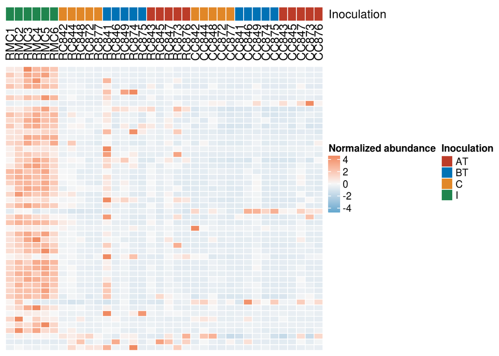

```r
##data preparation
genera_mature_heatmap_score$Inoculation <- factor(genera_mature_heatmap_score$Inoculation,levels = c("I","C","BT","AT"))
genus_matrix_score <- genera_mature_heatmap_score[-1:-2,-1:-2]
genus_matrix_score <- as.matrix(sapply(genus_matrix_score, as.numeric))
rownames(genus_matrix_score) <- rownames(genera_mature_heatmap_score)[-1:-2]
heatmap_annotation_rowname <- genera_mature_heatmap_score$Fraction

genus_diff_complexheatmap <- Heatmap(t(genus_matrix_score),
                                     col =colorRamp2(c(-4,0,4),rev(brewer.pal(3, name = 'RdBu'))),
                                     cluster_columns = FALSE,
                                     cluster_rows = FALSE,
                                     clustering_method_rows = 'average',
                                     clustering_distance_rows = 'spearman',#km = 3,
                                     #clustering_method_columns = 'average',
                                     #clustering_distance_columns = 'spearman', #km = 3,
                                     combined_name_fun = NULL,
                                     name = "Normalized abundance",
                                     rect_gp = gpar(col = "white", lty = 1, lwd = 1),
                                     top_annotation = HeatmapAnnotation(data.frame(#Fraction = factor(heatmap_annotation_rowname),
                                                                                   Inoculation = factor(genera_mature_heatmap_score$Inoculation[-1:-2])),
                                                                        col = list(Inoculation = c("AT"="#BC3C29FF","BT"="#0072B5FF","C"="#E18727FF","I"="#20854EFF"),
                                                                                   Fraction =c("Colon Epithelium"="#374E55FF","Colon Content"="#8B4F26","Rumen Epithelium"="#6A6599FF","Rumen Content"="#80796BFF") ),
                                                                        show_annotation_name = T,
                                                                        gap = unit(0.5,'mm'),
                                                                        gp = gpar(col = "white", lty = 1, lwd = 1)),
                                     row_dend_side = 'right',
                                     show_row_names = F,
                                     row_names_side = 'left',
                                     show_column_names = T,
                                     column_names_side = "top",
                                     row_names_max_width = unit(12,"cm")
)
genus_diff_complexheatmap
```

draft get! (remove the row name for better viewing, the name can be showed by change parameter: show_row_names = F to True) manually adjust on Adobe Illustrator (AI) amd combine the statistic result